# Enron Report

Carlos Jesus Caro

2025-09-14

## Submission Details

- **Email:** carlos.jesus-caro@edu.dsti.institute
- **Class:** [A24] Big Data Processing with R

## Summary

The goal of this project is to perform a comprehensive data analysis of the datasets provided in the Rdata file. This report will highlight the effective application of a range of data manipulation, cleaning, and transformation skills. These techniques are essential for preparing raw data for analysis, a process that accounts for a significant portion of the effort in any data-driven project. The successful execution of these tasks will demonstrate proficiency in creating a robust and reproducible analytical workflow.

## Analysis

### Loading thhe data and the libraries

```r
library(tidyverse)
load('Enron.Rdata')
```

### Collecting the data sets as data frames

```r
employees <- as.data.frame(employeelist)
messages <- as.data.frame(message)
recipients <- as.data.frame(recipientinfo)
```

### Data inspection

Identification of the variables within each data set

```r
employees_cols <- paste(colnames(employees), collapse = ", ")
sprintf("`employees` data frame column names: %s", employees_cols)
```

```
## [1] "`employees` data frame column names: eid, firstName, lastName, Email_id, Email2, Email3, EMail4, folder, status"
```

```r
messages_cols <- paste(colnames(messages), collapse = ", ")
sprintf("`messages` data frame column names: %s", messages_cols)
```

```
## [1] "`messages` data frame column names: mid, sender, date, message_id, subject"
```

```r
recipients_cols <- paste(colnames(recipients), collapse = ", ")
sprintf("`recipients` data frame column names: %s", recipients_cols)
```

```
## [1] "`recipients` data frame column names: rid, mid, rtype, rvalue"
```

Since every data frame has a unique ID, let’s check if there are any duplicates.

First, let’s define a function that returns the number of repeated values in a given data frame column.

```r
check_duplicates <- function(df, col_id) {
  rep <- df %>%
    group_by({{ col_id }}) %>%
    count() %>%
    filter(n > 1) %>%
    nrow()
  return(rep)
}
```

```r
sprintf("Number of duplicated IDs in `employees` data frame: %d", check_duplicates(employees, eid))
```

```
## [1] "Number of duplicated IDs in `employees` data frame: 0"
```

```r
sprintf("Number of duplicated IDs in `messages` data frame: %d", check_duplicates(messages, mid))
```

```
## [1] "Number of duplicated IDs in `messages` data frame: 0"
```

```r
sprintf("Number of duplicated IDs in `recipients` data frame: %d", check_duplicates(recipients, rid))
```

```
## [1] "Number of duplicated IDs in `recipients` data frame: 0"
```

Inspecting the field Status in Employees

```r
employees$status %>% unique()
```

```
##  [1] <NA>              Employee          N/A               CEO
##  [5] Director          Trader            President         Vice President
##  [9] Manager           Managing Director In House Lawyer
## 10 Levels: CEO Director Employee In House Lawyer Manager ... Vice President
```

It is clear that there are 2 values for NA, let’s consolidate:

```r
employees <- employees %>%
  mutate(status = as.character(status)) %>%
  mutate(status = na_if(status, "N/A")) %>%
  mutate(status = replace_na(status, "NA"))

employees %>%
  select(status) %>%
  unique()
```

```
##               status
## 1                 NA
## 2           Employee
## 5                CEO
## 6           Director
## 13            Trader
## 14         President
## 15    Vice President
## 24           Manager
## 28 Managing Director
## 37   In House Lawyer
```

```r
messages <- messages %>%
  filter(date >= as.Date('1999-01-01') & date <= as.Date('2002-12-31'))

sprintf("Number of messages between these years: %d", length(messages$date))
```

```
## [1] "Number of messages between these years: 252349"
```

Adding two new features in the `messages` data frame for easier filtration: year and month

```r
messages <- messages %>%
  mutate(
    year = year(date),
    year_month = format(date, "%Y-%m")
  )
```

Joining the tables messages, employees and recipients as it will facilitate further analysis

```r
# 1. Since each employee can have many email address, let's create a look up table
employee_lookup <- employees %>%
  pivot_longer(
    cols = starts_with("Email"),
    names_to = "email_type",
    values_to = "email_address"
  ) %>%
  select(eid, email_address, status) %>%
  drop_na()

# 2. Adding the employee ID to the messages data frame
messages <- messages %>%
  left_join(employee_lookup, by = c("sender" = "email_address")) %>%
  rename('sender_id' = eid, 'sender_status' = status)


# 3. Adding the employee ID to the recipient data frame
recipients <- recipients %>%
  left_join(employee_lookup, by = c("rvalue" = "email_address")) %>%
  rename('recipient_id' = eid, 'recipient_status' = status)

# 4. Joining messages and recipients data frames
complete <- inner_join(messages, recipients, by='mid')

# 5. Renaming rvalue to recipient
complete <- complete %>%
              rename(recipient = rvalue)
```

Saving ‘complete’ and ‘employees’ data frames

```r
saveRDS(complete, file = "complete.rds")
saveRDS(employees, file = "employees.rds")
```

### Data insights

When reviewing th data, the 3 data frames (employees, messages and recipients), this report will aim to answer the the following questions:

#### What is the proportion breakdown of employees based on status?

```r
total_employees <- length(employees$eid)

employees %>%
  group_by(status) %>%
  count(sort=TRUE) %>%
  rename(NumEmployees = n) %>%
  mutate(Proportion = round((NumEmployees / total_employees * 100), 2))
```

```
## # A tibble: 10 × 3
## # Groups:   status [10]
##    status            NumEmployees Proportion
##    <chr>                    <int>      <dbl>
##  1 Employee                    41      27.5
##  2 NA                          32      21.5
##  3 Vice President              23      15.4
##  4 Director                    14       9.4
##  5 Manager                     14       9.4
##  6 Trader                      13       8.72
##  7 CEO                          4       2.68
##  8 President                    4       2.68
##  9 Managing Director            3       2.01
## 10 In House Lawyer              1       0.67
```

#### What is the difference in volume in messages in between the dates of October 31, 2001 and December 2, 2001 and the overall volume?

```r
messages %>%
  group_by(year) %>%
  count() %>%
  rename('NumMessages' = n)
```

```
## # A tibble: 4 × 2
## # Groups:   year [4]
##    year NumMessages
##   <dbl>       <int>
## 1  1999        4760
## 2  2000       68707
## 3  2001      156320
## 4  2002       22562
```

Evidently, the year 2001 has a significant higher amount of messages compared to the other years. Diving into 2001

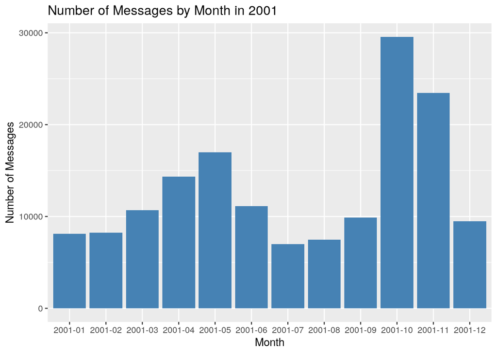

```r
count_2001 <- messages %>%
                filter(year == 2001) %>%
                group_by(year_month) %>%
                count() %>%
                rename('NumMessages' = n)

ggplot(data = count_2001, aes(x = year_month, y = NumMessages)) +
  geom_bar(stat = "identity", fill = "steelblue") +
  labs(
    title = "Number of Messages by Month in 2001",
    x = "Month",
    y = "Number of Messages"
  )
```

It becomes clear that the months of October and November 2001 had a significant number of emails than any other month in the same year.

#### How is the volume distribution among the different employee’s role?

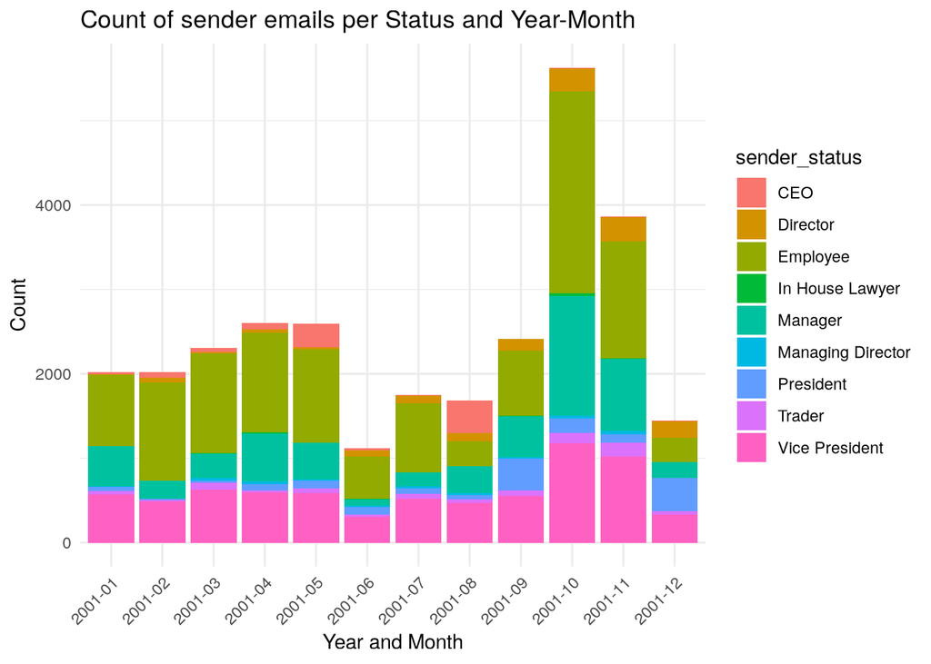

```r
complete_2001 <- complete %>%
  filter(year == 2001 & sender_status != "NA" & recipient_status != 'NA')

ggplot(data = complete_2001, aes(x = year_month, fill = sender_status)) +
  geom_bar() +
  labs(
    title = "Count of sender emails per Status and Year-Month",
    x = "Year and Month",
    y = "Count"
  ) +
  theme_minimal() +
  theme(axis.text.x = element_text(angle = 45, hjust = 1))
```

```r
sender_summary_proportion  <- complete_2001 %>%
                            group_by(year_month, sender_status) %>%
                            summarise(count = n(), .groups = 'drop') %>%
                            group_by(year_month) %>%
                            mutate(total_month = sum(count)) %>%
                            mutate(proportion = 100 * count / total_month) %>%
                            mutate(across(where(is.numeric), ~round(., 2))) %>%
                            select(-count, -total_month) %>%
                            pivot_wider(
                              names_from = year_month,
                              values_from = proportion
                            )

knitr::kable(sender_summary_proportion)
```

| sender_status | 2001-01 | 2001-02 | 2001-03 | 2001-04 | 2001-05 | 2001-06 | 2001-07 | 2001-08 | 2001-09 | 2001-10 | 2001-11 | 2001-12 |
| --- | --- | --- | --- | --- | --- | --- | --- | --- | --- | --- | --- | --- |
| CEO | 1.14 | 3.27 | 1.91 | 2.84 | 10.60 | 1.88 | 0.29 | 22.84 | 0.04 | 0.20 | 0.21 | 0.41 |
| Director | 0.59 | 2.87 | 0.69 | 1.65 | 1.00 | 6.55 | 5.04 | 5.93 | 5.71 | 4.76 | 7.35 | 13.75 |
| Employee | 41.49 | 57.50 | 51.39 | 45.47 | 42.71 | 44.57 | 46.79 | 17.73 | 31.86 | 42.56 | 36.02 | 19.77 |
| Manager | 23.86 | 10.60 | 12.50 | 21.53 | 16.65 | 6.55 | 9.45 | 18.62 | 20.19 | 25.10 | 22.10 | 12.85 |
| Managing Director | 0.45 | 0.15 | 1.39 | 1.42 | 0.58 | 2.06 | 1.66 | 1.42 | 0.54 | 0.66 | 0.88 | NA |
| President | 2.33 | 0.54 | 1.26 | 2.69 | 3.43 | 8.16 | 3.84 | 2.97 | 15.85 | 3.02 | 2.64 | 27.30 |
| Trader | 1.78 | 0.94 | 3.34 | 1.04 | 2.20 | 1.61 | 3.04 | 2.43 | 2.52 | 2.22 | 4.27 | 2.70 |
| Vice President | 28.37 | 24.12 | 27.39 | 22.79 | 22.67 | 27.80 | 29.90 | 28.05 | 22.92 | 20.89 | 26.36 | 23.22 |
| In House Lawyer | NA | NA | 0.13 | 0.58 | 0.15 | 0.81 | NA | NA | 0.37 | 0.60 | 0.18 | NA |

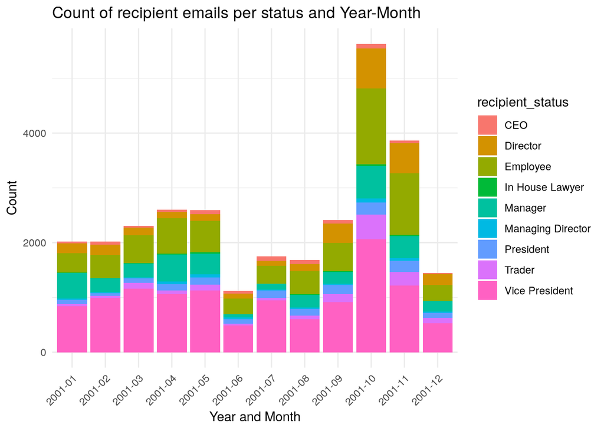

```r
ggplot(data = complete_2001, aes(x = year_month, fill = recipient_status)) +
  geom_bar() +
  labs(
    title = "Count of recipient emails per status and Year-Month",
    x = "Year and Month",
    y = "Count"
  ) +
  theme_minimal() +
  theme(axis.text.x = element_text(angle = 45, hjust = 1))
```

```r
recipient_summary_proportion  <- complete_2001 %>%
                            group_by(year_month, recipient_status) %>%
                            summarise(count = n(), .groups = 'drop') %>%
                            group_by(year_month) %>%
                            mutate(total_month = sum(count)) %>%
                            mutate(proportion = 100 * count / total_month) %>%
                            mutate(across(where(is.numeric), ~round(., 2))) %>%
                            select(-count, -total_month) %>%
                            pivot_wider(
                              names_from = year_month,
                              values_from = proportion
                            )

knitr::kable(recipient_summary_proportion)
```

| recipient_status | 2001-01 | 2001-02 | 2001-03 | 2001-04 | 2001-05 | 2001-06 | 2001-07 | 2001-08 | 2001-09 | 2001-10 | 2001-11 | 2001-12 |
| --- | --- | --- | --- | --- | --- | --- | --- | --- | --- | --- | --- | --- |
| CEO | 1.78 | 2.58 | 1.39 | 1.65 | 2.70 | 4.22 | 4.58 | 4.51 | 2.81 | 1.58 | 1.29 | 1.04 |
| Director | 8.91 | 9.51 | 6.03 | 4.57 | 4.86 | 7.62 | 4.93 | 7.77 | 14.52 | 12.88 | 14.20 | 14.31 |
| Employee | 17.48 | 20.75 | 21.96 | 24.75 | 22.28 | 25.83 | 19.07 | 24.73 | 21.56 | 24.62 | 29.11 | 19.83 |
| In House Lawyer | 0.40 | 0.35 | 0.26 | 0.50 | 0.69 | 0.36 | 0.06 | 1.13 | 0.41 | 0.64 | 0.49 | 0.62 |
| Manager | 22.82 | 12.53 | 10.98 | 18.92 | 14.80 | 4.93 | 5.73 | 13.58 | 9.02 | 10.41 | 10.56 | 12.85 |
| Managing Director | 1.44 | 0.84 | 0.82 | 1.92 | 2.04 | 3.23 | 1.26 | 1.42 | 0.87 | 1.28 | 1.14 | 1.87 |
| President | 3.47 | 2.58 | 3.52 | 4.30 | 5.20 | 7.17 | 7.85 | 7.00 | 6.91 | 4.01 | 5.38 | 6.43 |
| Trader | 2.08 | 1.83 | 4.64 | 2.76 | 3.97 | 3.05 | 2.52 | 4.33 | 6.16 | 7.94 | 6.29 | 6.36 |
| Vice President | 41.63 | 49.03 | 50.39 | 40.64 | 43.45 | 43.59 | 54.01 | 35.53 | 37.73 | 36.64 | 31.54 | 36.70 |

#### Did the patterns of message type (TO, CC, BCC) changed over the date range of interest?

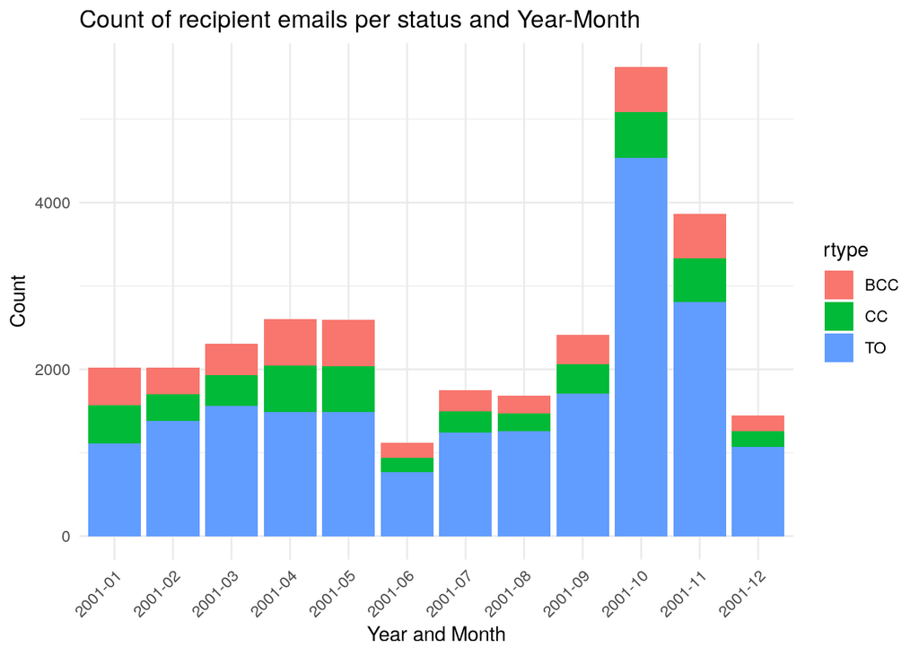

```r
ggplot(data = complete_2001, aes(x = year_month, fill = rtype)) +
  geom_bar() +
  labs(
    title = "Count of recipient emails per status and Year-Month",
    x = "Year and Month",
    y = "Count"
  ) +
  theme_minimal() +
  theme(axis.text.x = element_text(angle = 45, hjust = 1))
```

```r
complete_2001 %>%
  group_by(year_month, rtype) %>%
  count() %>%
  rename(NumMessages = n) %>%
  pivot_wider(id_cols = year_month, names_from = rtype, values_from = NumMessages)
```

```
## # A tibble: 12 × 4
## # Groups:   year_month [12]
##    year_month   BCC    CC    TO
##    <chr>      <int> <int> <int>
##  1 2001-01      454   454  1112
##  2 2001-02      319   319  1381
##  3 2001-03      373   373  1558
##  4 2001-04      559   559  1488
##  5 2001-05      555   555  1484
##  6 2001-06      174   174   767
##  7 2001-07      253   253  1240
##  8 2001-08      214   214  1258
##  9 2001-09      356   356  1705
## 10 2001-10      546   546  4538
## 11 2001-11      530   530  2805
## 12 2001-12      188   188  1071
```